# STAT 467 HW 2

İrem ÜSTEK

```r
data = read.csv("insurance.csv")
head(data)
```

```
##   age    sex    bmi children smoker    region   charges
## 1  19 female 27.900        0    yes southwest 16884.924
## 2  18   male 33.770        1     no southeast  1725.552
## 3  28   male 33.000        3     no southeast  4449.462
## 4  33   male 22.705        0     no northwest 21984.471
## 5  32   male 28.880        0     no northwest  3866.855
## 6  31 female 25.740        0     no southeast  3756.622
```

```r
str(data)
```

```
## 'data.frame':    1338 obs. of  7 variables:
##  $ age     : int  19 18 28 33 32 31 46 37 37 60 ...
##  $ sex     : chr  "female" "male" "male" "male" ...
##  $ bmi     : num  27.9 33.8 33 22.7 28.9 ...
##  $ children: int  0 1 3 0 0 0 1 3 2 0 ...
##  $ smoker  : chr  "yes" "no" "no" "no" ...
##  $ region  : chr  "southwest" "southeast" "southeast" "northwest" ...
##  $ charges : num  16885 1726 4449 21984 3867 ...
```

```r
dim(data)
```

```
## [1] 1338    7
```

# Multivariate Chi-Square QQ Plot

```r
data_a = data[,c(3,7)]
head(data_a)
```

```
##      bmi   charges
## 1 27.900 16884.924
## 2 33.770  1725.552
## 3 33.000  4449.462
## 4 22.705 21984.471
## 5 28.880  3866.855
## 6 25.740  3756.622
```

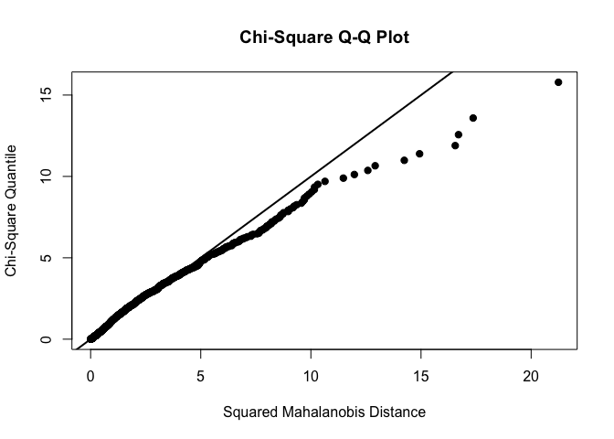

```
## $multivariateNormality
##              Test        Statistic               p value Result
## 1 Mardia Skewness 572.819662744377 1.18111529119205e-122     NO
## 2 Mardia Kurtosis  5.8874916226192  3.92101040525006e-09     NO
## 3             MVN             <NA>                  <NA>     NO
##
## $univariateNormality
##           Test  Variable Statistic   p value Normality
## 1 Shapiro-Wilk    bmi       0.9939  <0.001      NO
## 2 Shapiro-Wilk  charges     0.8147  <0.001      NO
##
## $Descriptives
##            n       Mean      Std.Dev   Median      Min      Max       25th
## bmi     1338    30.6634     6.098187   30.400   15.960    53.13   26.29625
## charges 1338 13270.4223 12110.011237 9382.033 1121.874 63770.43 4740.28715
##                75th      Skew    Kurtosis
## bmi        34.69375 0.2834106 -0.05942352
## charges 16639.91251 1.5124825  1.58895424
```

```r
#Multivariate Chi-Square QQ Plot

mvn(data_a, multivariatePlot = "qq")
```

Above Chi-Square QQ-Plot indicates non- normality. Although it seemed okay for the initial points, there are too many departures from the straight line for the rest of the graph. So, there is a suspicion on the normality and should be proved using an official normality test.

# Multivariate Normality Test

For the statistical normality tests that will be utilized, the following hypothesis is valid:

$H_0$: $\text{The data follows normal distribution.}$

$H_1$: $\text{The data does not follow normal distribution.}$

Here, since data has 1338 rows, Royston MVN Test and Henze-Zirklers MVN Test will be applied.

## Royston MVN Test

```r
mvn(data = data_a, mvnTest = "royston")$multivariateNormality
```

```
##      Test        H      p value MVN
## 1 Royston 177.5921 2.735019e-39  NO
```

## Henze-Zirklers MVN Test

```r
mvn(data = data_a, mvnTest = "hz")$multivariateNormality
```

```
##            Test       HZ p value MVN
## 1 Henze-Zirkler 38.19521       0  NO
```

- Both tests have p-value less than $\alpha$ = 0.05, thus there is not enough evidence to conclude that the data follow a normal distribution. They suggest that the data with BMI and Carges is not normal.
- In that case, there are some procedures that can be followed:
- The reason causing the non-normality can be detected. This can be due to the outliers. Again, multivariate outlier detection methods can be utilized by Mahalanobis Distance. These points can be removed from the data, or replaced with more robust statistics, such as median.
- We can apply transfomation to the data, and then test for the normality one more time. For example, Box-Cox Power transformation could be useful.
- If this is an ongoing study, the sample size can be increased. However, most of the time it is not practical and may be time & money wasting.
- Generating bootstrap samples can be helpful as well because we are simply resampling the data that we have.
- If none of them work to make the data normal, non-parametric methods can be utilized.
- However, for the upcoming analyses, we will assume normality for this data.

Here, since we will be testing that wheter our reponses,BMI and Charges, vary with smoking status or not, we will have the following hypothesis:

$H_0$: $\mu_{smoker}$ = $\mu_{nonsmoker}$

$\mu_{smoker}$ = $[\mu_{BMI/smoker}$, $\mu_{Charges/smoker} ]$

$\mu_{nonsmoker}$ = $[\mu_{BMI/nonsmoker}$, $\mu_{Charges/nonsmoker}]$

## Hotelling’s Two Sample T2- Test

- After assuming normality and constructing the hypothesis above, we can apply Hotelling’s Two Sample T2- Test on the data to see whether BMI & Charges changes according to the smoking status.

```r
HotellingsT2(cbind(data$bmi,data$charges) ~ data$smoker)
```

```
##
##  Hotelling's two sample T2-test
##
## data:  cbind(data$bmi, data$charges) by data$smoker
## T.2 = 1207.2, df1 = 2, df2 = 1335, p-value < 2.2e-16
## alternative hypothesis: true location difference is not equal to c(0,0)
```

- P-value of the test is found as close to 0 which is less than $\alpha$. Thus, there is enough evidence to conclude that the mean of BMI and Charges vary according to the smoking status at 95% confidence level.

# K-Means Clustering

To prepare our data to K-means clustering, all data must contain numerical values. Thus, we converted categorical variables of Sex and Smoker as dummies.

```r
data$sex_n<-ifelse(data$sex=="female",1,0)
data$smoker_n<-ifelse(data$smoker=="yes",1,0)
data1<-data[,-c(2,5,6)]
```

Here, with the help of K-Means clustering,which is an unsupervised learning method, we try to cluster our data into pre-defind subgroups by finding homogenous features among them.

## Scaling

```r
data1_sc = scale(data1)
head(data1_sc)
```

```
##             age        bmi    children    charges      sex_n   smoker_n
## [1,] -1.4382265 -0.4531506 -0.90827406  0.2984722  1.0101410  1.9698501
## [2,] -1.5094011  0.5094306 -0.07873775 -0.9533327 -0.9892209 -0.5072734
## [3,] -0.7976553  0.3831636  1.58033487 -0.7284023 -0.9892209 -0.5072734
## [4,] -0.4417824 -1.3050431 -0.90827406  0.7195739 -0.9892209 -0.5072734
## [5,] -0.5129570 -0.2924471 -0.90827406 -0.7765118 -0.9892209 -0.5072734
## [6,] -0.5841316 -0.8073542 -0.90827406 -0.7856145  1.0101410 -0.5072734
```

# Determining Optimal Number of Clusters

```r
unique(data$region)
```

```
## [1] "southwest" "southeast" "northwest" "northeast"
```

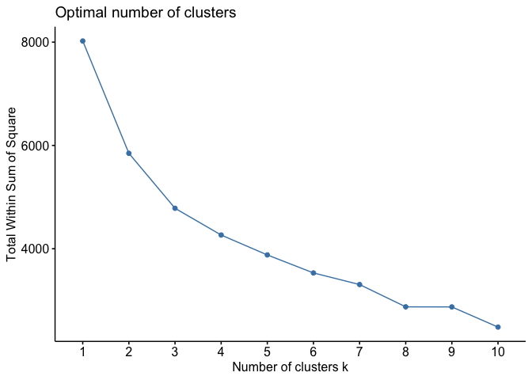

```r
set.seed(123)
fviz_nbclust(data1_sc, kmeans, method = "wss")
```

-However, as stated, the data has 4 different regions, which are “southwest”, “southeast”, “northwest”,“northeast”. However, we have found optimal 8 different homogenous clusters among the data. These regions may have different patterns inside.

## K- Means Clustering with k=8

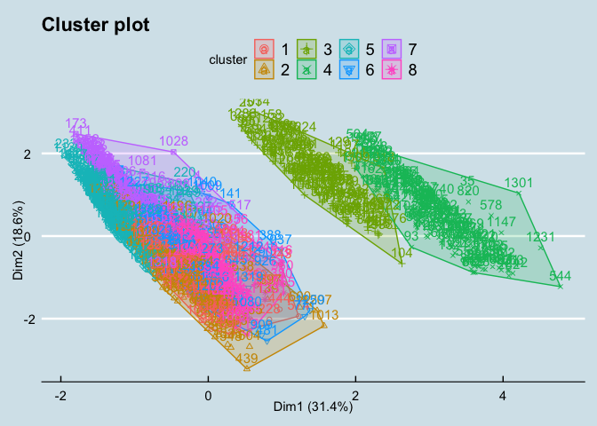

```r
set.seed(123)
final = kmeans(data1_sc, centers= 8, nstart = 25)
fviz_cluster(final, data = data1_sc)+theme_economist()
```

# Data Splitting

```r
set.seed(123)
split <- initial_split(data1, prop = .8)
train <- training(split)
test  <- testing(split)

dim(train)
```

```
## [1] 1071    6
```

```r
dim(test)
```

```
## [1] 267   6
```

# Multiple Linear Regression Model on BMI

```r
str(train)
```

```
## 'data.frame':    1071 obs. of  6 variables:
##  $ age     : int  19 18 28 33 32 31 46 37 37 60 ...
##  $ bmi     : num  27.9 33.8 33 22.7 28.9 ...
##  $ children: int  0 1 3 0 0 0 1 3 2 0 ...
##  $ charges : num  16885 1726 4449 21984 3867 ...
##  $ sex_n   : num  1 0 0 0 0 1 1 1 0 1 ...
##  $ smoker_n: num  1 0 0 0 0 0 0 0 0 0 ...
```

```r
fit_lm = lm(data=train, formula= bmi~.)
summary(fit_lm)
```

```
##
## Call:
## lm(formula = bmi ~ ., data = train)
##
## Residuals:
##      Min       1Q   Median       3Q      Max
## -16.2818  -3.6908  -0.1656   3.2863  20.9447
##
## Coefficients:
##               Estimate Std. Error t value Pr(>|t|)
## (Intercept)  2.943e+01  5.721e-01  51.436   <2e-16 ***
## age         -3.163e-02  1.452e-02  -2.179   0.0296 *
## children     2.656e-02  1.473e-01   0.180   0.8569
## charges      2.917e-04  2.766e-05  10.546   <2e-16 ***
## sex_n       -2.648e-01  3.492e-01  -0.758   0.4484
## smoker_n    -6.905e+00  7.800e-01  -8.853   <2e-16 ***
## ---
## Signif. codes:  0 '***' 0.001 '**' 0.01 '*' 0.05 '.' 0.1 ' ' 1
##
## Residual standard error: 5.69 on 1065 degrees of freedom
## Multiple R-squared:  0.1082, Adjusted R-squared:  0.104
## F-statistic: 25.84 on 5 and 1065 DF,  p-value: < 2.2e-16
```

- In the regression output, it is seen that Children and Sex_n variables are not significant. And Adjusted R Square of the model is quite low. Thus, it could be a better idea to use backward elimination for this model.

# Backward Elimination

```r
fit_lm = stepAIC(fit_lm, direction = "backward",trace=FALSE)
summary(fit_lm)
```

```
##
## Call:
## lm(formula = bmi ~ age + charges + smoker_n, data = train)
##
## Residuals:
##      Min       1Q   Median       3Q      Max
## -16.1780  -3.6680  -0.1873   3.2660  21.0833
##
## Coefficients:
##               Estimate Std. Error t value Pr(>|t|)
## (Intercept)  2.931e+01  5.246e-01  55.876   <2e-16 ***
## age         -3.174e-02  1.451e-02  -2.187   0.0289 *
## charges      2.921e-04  2.753e-05  10.611   <2e-16 ***
## smoker_n    -6.884e+00  7.770e-01  -8.859   <2e-16 ***
## ---
## Signif. codes:  0 '***' 0.001 '**' 0.01 '*' 0.05 '.' 0.1 ' ' 1
##
## Residual standard error: 5.686 on 1067 degrees of freedom
## Multiple R-squared:  0.1077, Adjusted R-squared:  0.1052
## F-statistic: 42.92 on 3 and 1067 DF,  p-value: < 2.2e-16
```

- As expected, Sex_n and Children variables are removed from the model because they do not contribute to the model. Adjusted R-Square increased from 0.104 to 0.1052 which is quite low for a train model.
- Performance of the model should be check using test data.

# Prediction of BMI on the Test Data

```r
pred = predict(fit_lm, test)
rmse=rmse(test$bmi, pred)
rmse
```

```
## [1] 6.135039
```

- It is found that RMSE= 6.135.

# Decision Tree Clustering

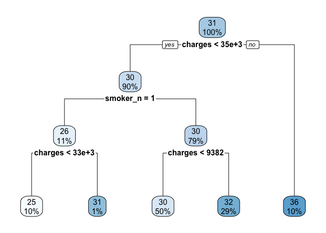

```r
fit_dt = rpart(bmi~., data=train, method='anova') # Since we are dealing with a regression case, we defined method as 'anova'.

rpart.plot(fit_dt)
```

- The decision tree above is constrcted with the default parameters. However, we can improve it by finding optimal parameters with Parameter Tuning.

## Parameter Tuning

```r
hyper_grid <- expand.grid(
  minsplit = seq(5, 20, 1),
  maxdepth = seq(8, 15, 1)
)

# total number of combinations
nrow(hyper_grid)
```

```
## [1] 128
```

```r
models <- list() #create a list object

for (i in 1:nrow(hyper_grid)) {

  # get minsplit, maxdepth values at row i
  minsplit <- hyper_grid$minsplit[i]
  maxdepth <- hyper_grid$maxdepth[i]

  # train a model and store in the list
  models[[i]] <- rpart(
    formula = bmi ~ .,
    data    = train,
    method  = "anova",
    control = list(minsplit = minsplit, maxdepth = maxdepth)
    )
}

# function to get optimal cp
get_cp <- function(x) {
  min    <- which.min(x$cptable[, "xerror"])
  cp <- x$cptable[min, "CP"]
}

# function to get minimum error
get_min_error <- function(x) {
  min    <- which.min(x$cptable[, "xerror"])
  xerror <- x$cptable[min, "xerror"]
}

hyper_grid %>%
  mutate(
    cp    = purrr::map_dbl(models, get_cp),
    error = purrr::map_dbl(models, get_min_error)
    ) %>%
  arrange(error) %>%
  top_n(-5, wt = error)
```

```
##   minsplit maxdepth   cp     error
## 1        9       12 0.01 0.8607394
## 2        7       10 0.01 0.8614233
## 3        7       15 0.01 0.8614463
## 4       12       12 0.01 0.8641466
## 5        5        8 0.01 0.8644459
```

## Final Optimal Decision Tree

```r
optimal_tree <- rpart(
    formula = bmi ~ .,
    data    = train,
    method  = "anova",
    control = list(minsplit = 11, maxdepth = 14, cp = 0.01)
    )

# Prediction on BMI in Test Data
pred <- predict(optimal_tree, newdata = test)
rmse(test$bmi,pred)
```

```
## [1] 5.997439
```

# Bagging with 10-fold corss validation

- Now, rather than fitting only one decision tree, we will use multiple models and use their average in order to decrease the variance.

```r
ctrl <- trainControl(method = "cv",  number = 10)

# CV bagged model
bagged_cv <- train(
  bmi ~ .,
  data = train,
  method = "treebag",
  trControl = ctrl,
  importance = TRUE
  )

# assess results
bagged_cv
```

```
## Bagged CART
##
## 1071 samples
##    5 predictor
##
## No pre-processing
## Resampling: Cross-Validated (10 fold)
## Summary of sample sizes: 964, 966, 965, 964, 964, 963, ...
## Resampling results:
##
##   RMSE      Rsquared   MAE
##   5.521979  0.1561109  4.356526
```

## OOB RMSE

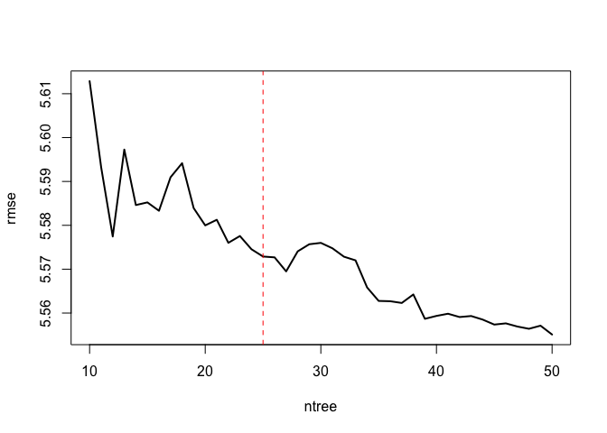

```r
# assess 10-50 bagged trees
ntree <- 10:50

# create empty vector to store OOB RMSE values
rmse <- vector(mode = "numeric", length = length(ntree))

for (i in seq_along(ntree)) {
  # reproducibility
  set.seed(123)

  # perform bagged model
  model <- bagging(
  formula = bmi ~ .,
  data    = train,
  coob    = TRUE,
  nbagg   = ntree[i]
)
  # get OOB error
  rmse[i] <- model$err
}

plot(ntree, rmse, type = 'l', lwd = 2)
abline(v = 25, col = "red", lty = "dashed")
```

## RMSE

```r
rmse(test$bmi, predict(bagged_cv,test))
```

```
## [1] 5.963737
```